# vitD

Aijing Zhang

July 17, 2017

## Load the data

First load the data

1. a dataset relating physiologic response to serum level (priemelDataReconstruction.csv).
2. a dataset summarizing results from several clinical trials relating dietary intake levels in IU to serum levels in nmol/L, mostly transcribed from Table 5-4 in the IOM report (iomReview.csv). Careful with this one; it was assembled for human readability, and has blank lines.
3. metadata for the dose response dataset (vitD.R).

```r
mydata <- read.csv(file="priemelDataReconstruction.csv", header=TRUE, sep=",")
mydata2 <- read.csv(file="iomReview.csv", header=TRUE, sep=",")
library(dplyr)
library(ggplot2)
```

Reconstructed data have 675 rows. Review data have 43 rows. Here’s the first rows of datat:

```r
head(mydata)
```

```
##   SerumLevelInNgPerMl OV.BV
## 1                7.49     0
## 2               12.00     0
## 3                7.49     0
## 4                2.09     0
## 5                9.12     0
## 6                4.59     0
```

```r
head(mydata2)
```

```
##            Study  N Dose DietaryIntake TotalIntake AchievedLevel   SD
## 1                NA   NA            NA          NA            NA   NA
## 2 AlaHouhala1988 27    0           200         200          43.3 19.5
## 3 AlaHouhala1988 24  400           200         600          71.3 23.8
## 4                NA   NA            NA          NA            NA   NA
## 5    Cashman2008 57    0           136         136          37.4   NA
## 6    Cashman2008 48  200           172         372          49.7   NA
##   IOMIntake IOMLevel Age.Group InTable5p4  Color  Symbol PlotSymbol
## 1        NA       NA                                             NA
## 2       200     43.3     Young          y yellow  Circle         21
## 3       600     71.3     Young          y yellow  Circle         21
## 4        NA       NA                                             NA
## 5       135     37.4     Adult          y   blue Diamond         23
## 6       372     49.7     Adult          y   blue Diamond         23
```

## Plot the data

Plot the physiologic response (OV/BV) as a function of serum level.

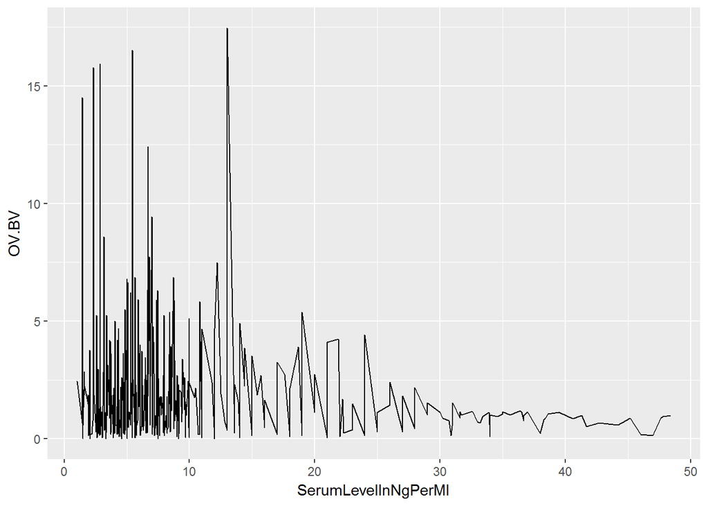

```r
ggplot(mydata, aes(x=SerumLevelInNgPerMl, y=OV.BV)) +
    geom_line()
```

## Fit the data

Using logistic regression to fit the probability that requirements are met (OV/BV is 2 or less) as a function of serum level.

```r
model <- glm(OV.BV<=2 ~.,family=binomial(link='logit'),data=mydata)
summary(model)
```

```
##
## Call:
## glm(formula = OV.BV <= 2 ~ ., family = binomial(link = "logit"),
##     data = mydata)
##
## Deviance Residuals:
##     Min       1Q   Median       3Q      Max
## -2.0360  -1.4874   0.7576   0.8260   0.8963
##
## Coefficients:
##                     Estimate Std. Error z value Pr(>|z|)
## (Intercept)          0.63719    0.13751   4.634 3.59e-06 ***
## SerumLevelInNgPerMl  0.04646    0.01257   3.696 0.000219 ***
## ---
## Signif. codes:  0 '***' 0.001 '**' 0.01 '*' 0.05 '.' 0.1 ' ' 1
##
## (Dispersion parameter for binomial family taken to be 1)
##
##     Null deviance: 768.35  on 674  degrees of freedom
## Residual deviance: 751.53  on 673  degrees of freedom
## AIC: 755.53
##
## Number of Fisher Scoring iterations: 4
```

```r
mydatasub <- subset(mydata,SerumLevelInNgPerMl<=10)
```